# Coursework Report

*N* removed NAs: 3

*N* removed typo: 1

*N* removed <18: 14

*N* total clean: 132

| Group | *N* | *M*<sub>age</sub> | *M*<sub>rating</sub> |
| --- | --- | --- | --- |
| Control | 68 | 20.6 | 6.13 |
| Experim | 64 | 20.8 | 5.20 |

**Main analysis results**

*t*(130) = 7.79, *p* < .001

[interactive chart not shown]

[figure not shown]

[interactive chart not shown]

# Coursework Report

Analysing Data, Spring 2020

# Methods

The method section includes the participants and the design section. The following participant section describes the participant descriptives and the design section explains the hypothesis and variables in the original study which is the same for this replication study.

## Participants

Initially, there were 150 people who participated in the study. However, these participants needed to be filtered out. I removed participants who were under 18 as they cannot consent to the study due to unethical age. Participants who did not include their age (i.e. the age was NA) were removed from the dataset as we cannot formulate tables and tests if this data is not included. Participants were also removed if their age was mistyped and had letters such as 2q, meaning the data cound not be interpreted as a numeric. After cleaning the data, and filtering out these participants, there were 18 participants removed leaving a total of 132 participants.

The following table represents the mean, standard deviation and range of participants ages.

| mean | sd | min | max |
| --- | --- | --- | --- |
| 20.7 | 1.85 | 18 | 27 |

The following table represents participant descriptives by experimental condition.

| condition | n | mean | sd |
| --- | --- | --- | --- |
| White | 68 | 20.6 | 1.68 |
| Red | 64 | 20.8 | 2.02 |

## Design

The conceptual hypothesis/ the research question that we are investigating is whether colour influences attractiveness.

The independent variable used in our analysis was the colour condition which was a factor. This condition was operationalised by participants seeing a picture of a man surrounded by a coloured background; either white or red. The control group saw a white background and the experimental group saw the red background.

The dependent variable used in our analysis was the mean attractive rating on a scale of 1-9. Women were shown the photos and asked three questions: How attractive do you think this person is?, How pleasant is this person to look at?, If I were to meet the person in this picture face to face, I would think he is attractive. They were asked to answer these questions by giving a rating of 1-9 for each question. The average of the answers was calculated to give a composite score for each condition. The response of 1-9 was interpreted as the higher the number the more attractive they found the man in the image, and the closer to 1 their rating was, the less attractive they found the man.

The operational hypothesis is that women will rate men as more attractive when the image of the man is surrounded by a red frame and women will rate men as less attractive when the image of the man is surrounded by a white frame. The test we will use to test this hypothesis is the student t-test.

# Results

The changes made to the data was calculating the composite score which is the accumulated means from the ratings given in response to the three questions asked about the image. Ratings were given out of a choice of 1-9 and the mean value was calculated based on these values. Two composite scores were calculated; on for the white control condition and one for the red experimental condition.

The following table shows the statistical test we used, which was the student t-test, to determine whether the results were or were not significant. Also, the bottom row of the table shows the composite mean rating score in each condition.

```
##
##  Two Sample t-test
##
## data:  opinion_comp by condition
## t = 8, df = 130, p-value = 0.000000000002
## alternative hypothesis: true difference in means is not equal to 0
## 95 percent confidence interval:
##  0.697 1.172
## sample estimates:
## mean in group White   mean in group Red
##                6.13                5.20
```

The mean rating score in the red condition was 5.19(2dp) and the mean rating score for the white condition was 6.13(2dp. The difference in the mean score between conditions was 0.94, meaning women rated men more attractive on average when they were associated with the colour white.

The test used to determine whether these results were significant was the student t-test. The table above shows the results of the t-test, which was 7.79(2dp). The critical value we are comparing this score to is 2.58 based on 130 degrees of freedom and a p-value of 1.918e-12, taken from a table of critical values. This critical value is therefore lower than the calculated T value of 7.79 meaning the results were significant. This means that, the man in the white condition was perceived to be more attractive than the man in the red condition. This goes against our operational hypothesis of women finding men more attractive in conjunction with the colour red.

The following plot shows a visual representation of the difference in mean rating of attractiveness in both colour conditions.

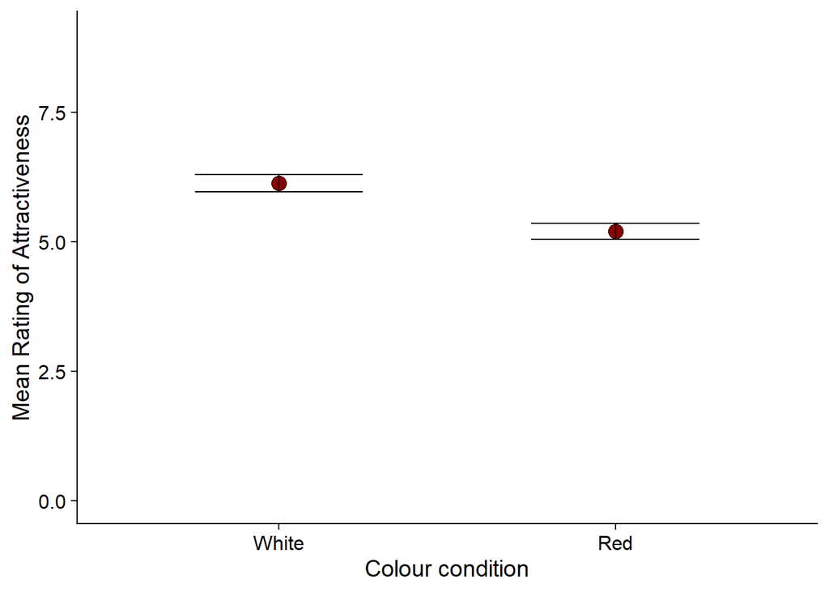

# Discussion

The results do not support the original hypothesis of men being seen as more attractive in conjunction with the colour red. Our results show that on average, women found men more attractive in conjunction with the colour white.

The original study results claim to find a significant correlation between men’s attractiveness ratings and being associated with the colour red. They claim that a significant effect was found as “women in the red condition rated the target men as more attractive than did those in the blue condition” (Elliot, et al., 2010). These results of the original study differ from those of this replication study because the replication study results show that women found men more attractive on average when associated with the control: white. This could mean that the findings are insignificant because the effect of red influencing attractiveness is not strong enough to be generalised to other studies and it is therefore unreliable to generalise levels of attractiveness to a colour. It could also mean different participants will be less influenced by the effect of colour compared to women of other backgrounds i.e. women of different age groups, from different ethnic groups or from different educational backgrounds. The participants in the original study consisted of 21 female undergraduates from different ethnic backgrounds, although all from the US (Elliot, et al., 2010). The data on participants in the replication study does not describe the participants in this level of detail, although it mentions that they are undergraduates from the University of Sussex, leaving the option open that the difference in results are dissimilar due to participant differences, such as cultural ones.

Based off of the results from this replication study and other research done in this area, I would suggest in conclusion, that the investigated effect is present minimally at best. However, I would argue that the findings from Elliot’s study are statistically irrelevant, as mentioned in previous research.

# References

Elliot, A., Kayser, D., Greitemeyer, T., Litchenfeld, S., Gramzow, R., & Maier, M. (2010). Red, Rank and Romance in Women Viewing Men. Journal of Experimental Psychology, 399-417. *Journal of Experimental Psychology: General, 139*(3), 399.

Francis, G. (2013). Publication Bias in “Red, Rank, and Romance in Women Viewing Men,” by Elliot et al. 2010. Journal of Experimental Psychology, 292-296. *Journal of Experimental Psychology: General, 139*(3), 399.

Peperkoorn, L., Roberts, S., & Pollet, T. (2016). Revisiting the Red Effect on Attractiveness and Sexual Reciprocity: No Effect of the Color Red on Human Mate Preferences. Evolutionary Psychology, 1-13. *Journal of Experimental Psychology: General, 139*(3), 399.